# Hierarchical clustering + SOM

Jose Rodr?guez Maldonado

Practice 1. Part 1 & Part 2. Computational learning  
jrmaj0a@uma.es

Octubre de 2018

# Part 1: Hierarchical clustering

## Herachical clustering

I am going to start this practice talking a bit about the shilouette value. It’s a measure of how similar an object is to its own cluster (cohesion) compared to other clusters (separation).

The silhouette ranges are [-1,1], where a high value indicates that the object is well matched to its own cluster and poorly matched to neighboring clusters.

The silhouette can be calculated with any distance metric, such as the Euclidean distance.

### Perform hierarchical clustering

We start reading the data frame.

```r
data.frame <- read.csv("datos1.csv", header=TRUE, sep= ";", dec=",")
kable(data.frame[1:10,]) %>%
  kable_styling(bootstrap_options = "striped", full_width = F)
```

| Genes | t0 | t0.5 | t2 | t5 | t7 | t9 | t11.5 |
| --- | --- | --- | --- | --- | --- | --- | --- |
| YAL025C | 1.163781 | -1.758143 | -0.314950 | 0.283874 | -0.677900 | 0.470183 | 0.833156 |
| YAL036C | 0.955552 | -1.489560 | -0.499057 | -0.099143 | -0.674453 | 1.414381 | 0.392280 |
| YAL040C | 1.454598 | -0.735149 | -0.073602 | -0.618896 | -0.789697 | 1.391507 | -0.628760 |
| YDL037c | 1.698578 | -1.268638 | -0.375511 | 0.996817 | -0.319158 | -0.344837 | -0.387251 |
| YDR184C | 1.302831 | -1.338633 | -0.555163 | -0.101402 | -0.674167 | 1.317301 | 0.049233 |
| YDR299W | 1.431937 | -1.819908 | 0.056708 | 0.628218 | -0.461532 | 0.001474 | 0.163103 |
| YDR380W | 0.472715 | -1.713187 | -0.916225 | -0.131575 | 0.433669 | 0.731209 | 1.123394 |
| YDR398W | 1.235163 | -1.796627 | -0.062241 | 0.416590 | -0.767331 | 0.539733 | 0.434713 |
| YER006w | 1.927985 | -1.138106 | -0.583176 | 0.056551 | -0.731212 | 0.225849 | 0.242109 |
| YER064c | 1.937260 | -1.094734 | -0.423042 | -0.165499 | -0.823443 | 0.316565 | 0.252894 |

Now, we are going to try different clustering types:

- Avarage
- Complete
- Single

Also, we are going to try different distance metrics. The euclidean, and the ccorrelation ‘distance’, which is the most common in the microarray studies.

- Correlation
- Euclidean

```r
#First we are going to scale the data in order to obtain a more reliable result
data.matrix<-as.matrix(data.frame)
data.matrix<-data.matrix[,-1]
data.matrix<-mapply(data.matrix, FUN=as.numeric)
data.matrix<-matrix(data=data.matrix, ncol=7)
data.scaled<-scale(data.matrix)

hcut.eu.av <- hcut(dist(data.scaled), k=5, hc_method = "average", hc_metric = "euclidean")
hcut.eu.comp <- hcut(dist(data.scaled), k=5, hc_method = "complete", hc_metric = "euclidean")
hcut.eu.sing <- hcut(dist(data.scaled), k=5, hc_method = "single", hc_metric = "euclidean")
hcut.pea.av <- hcut(dist(data.scaled), k=5, hc_method = "average", hc_metric = "correlation")
hcut.pea.comp <- hcut(dist(data.scaled), k=5, hc_method = "complete", hc_metric = "correlation")
hcut.pea.sing <- hcut(dist(data.scaled), k=5, hc_method = "single", hc_metric = "correlation")
```

Here, we can see the different cluster trees obtained.

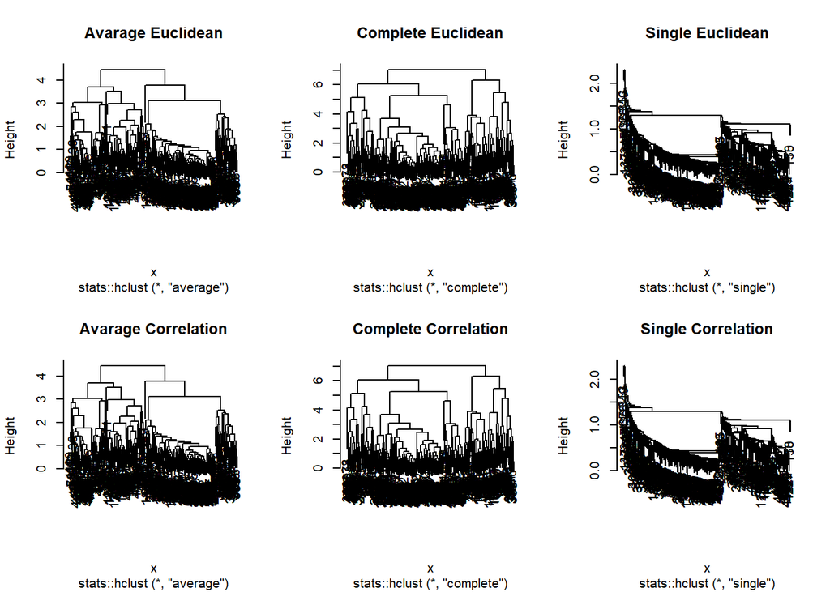

```r
par(mfrow=c(2,3))
plot(hcut.eu.av, main="Avarage Euclidean")
plot(hcut.eu.comp, main="Complete Euclidean")
plot(hcut.eu.sing, main="Single Euclidean")
plot(hcut.pea.av, main="Avarage Correlation")
plot(hcut.pea.comp, main="Complete Correlation")
plot(hcut.pea.sing, main="Single Correlation")
```

### Silhouette indexes

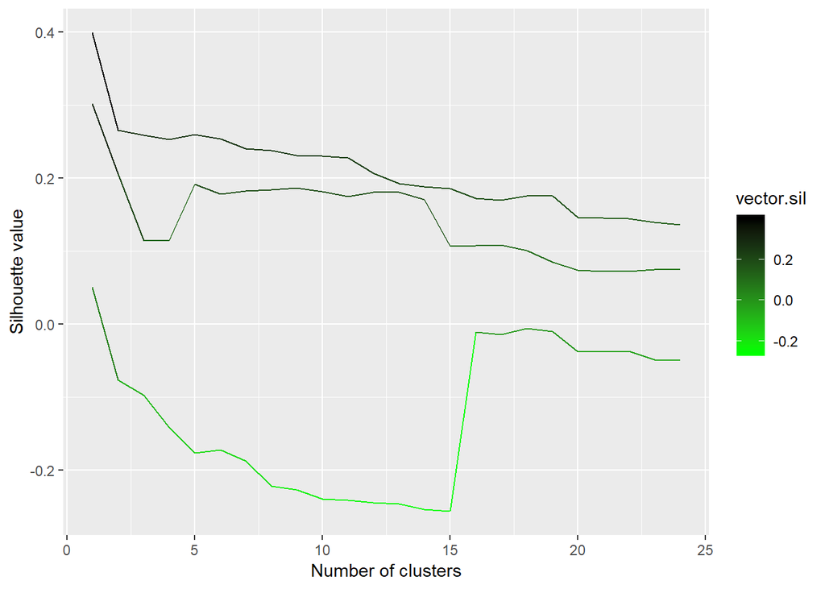

```r
plot.Silhouette<-function(cluster, data, range){
  vector.sil<-c()
  x<-c()
  if(min(range)<=1){
    print("NUMBER OF CLUSTERS BIGGER THAN 1")
    break()
  }
  else{
  for(i in 1:length(range)){
    cut<-cutree(cluster, k = range[i])
    #show(table(cut))
    si4 <- silhouette(cut, daisy(data))
    vector.sil<-c(vector.sil,mean(si4[,3]))
    x<-c(x,i)
  }
  data<-data.frame(x,vector.sil)

  }
  return(data)
}


var.eu<-plot.Silhouette(hcut.eu.av, data.frame, range=2:25)
var1.eu<-plot.Silhouette(hcut.eu.comp, data.frame, range=2:25)
var2.eu<-plot.Silhouette(hcut.eu.sing, data.frame, range=2:25)
var.pea<-plot.Silhouette(hcut.pea.av, data.frame, range=2:25)
var1.pea<-plot.Silhouette(hcut.pea.comp, data.frame, range=2:25)
var2.pea<-plot.Silhouette(hcut.pea.sing, data.frame, range=2:25)

ggplot() +
  geom_line(data = var.eu, aes(x = x, y = vector.sil, color=vector.sil))+
  geom_line(data = var1.eu, aes(x = x, y = vector.sil, color=vector.sil))+
  geom_line(data = var2.eu, aes(x = x, y = vector.sil, color=vector.sil)) +
  geom_line(data = var.pea, aes(x = x, y =vector.sil, color=vector.sil))+
  geom_line(data = var1.pea, aes(x = x, y = vector.sil, color=vector.sil))+
  geom_line(data = var2.pea, aes(x = x, y = vector.sil, color=vector.sil)) +
  xlab('Number of clusters') +
  ylab('Silhouette value') +
  scale_color_gradient(low = "green", high = "black")
```

The first thing that we can tell about this picture is that we only have 3 different lines in stead of 6, as expected. That occurs because the results that we have for correlation’s and for the euclidean’s distance is the same. As we can see as follows:

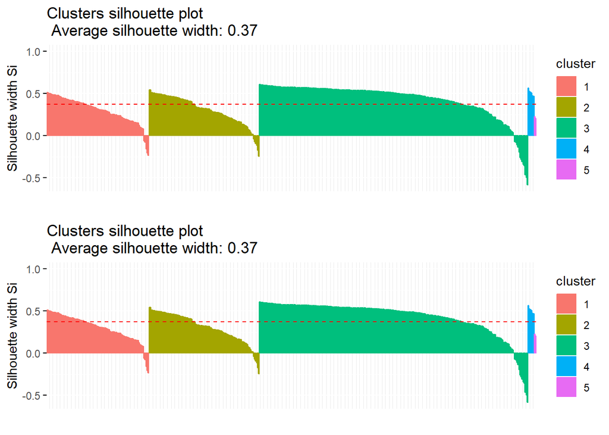

```
##   cluster size ave.sil.width
## 1       1   99          0.30
## 2       2  107          0.31
## 3       3  260          0.43
## 4       4    6          0.51
## 5       5    2          0.22
##   cluster size ave.sil.width
## 1       1   99          0.30
## 2       2  107          0.31
## 3       3  260          0.43
## 4       4    6          0.51
## 5       5    2          0.22
```

```r
grid.arrange(fviz_silhouette(hcut.eu.av), fviz_silhouette(hcut.pea.av), ncol=1,nrow= 2)
```

The results are exactly the same:

```r
var.eu == var.pea
```

```
##          x vector.sil
##  [1,] TRUE       TRUE
##  [2,] TRUE       TRUE
##  [3,] TRUE       TRUE
##  [4,] TRUE       TRUE
##  [5,] TRUE       TRUE
##  [6,] TRUE       TRUE
##  [7,] TRUE       TRUE
##  [8,] TRUE       TRUE
##  [9,] TRUE       TRUE
## [10,] TRUE       TRUE
## [11,] TRUE       TRUE
## [12,] TRUE       TRUE
## [13,] TRUE       TRUE
## [14,] TRUE       TRUE
## [15,] TRUE       TRUE
## [16,] TRUE       TRUE
## [17,] TRUE       TRUE
## [18,] TRUE       TRUE
## [19,] TRUE       TRUE
## [20,] TRUE       TRUE
## [21,] TRUE       TRUE
## [22,] TRUE       TRUE
## [23,] TRUE       TRUE
## [24,] TRUE       TRUE
```

In addition, the result obtained seems to be very low for low number of clusters. So, I have decided to track all the values that the silhouette index has through the different number of clusters.

```r
load(file="savedData/optimalClust.RData")
```

Due to the fact that the results given by the variance are the same as the ones that we can get by the euclidean distance. I have decided to use just one of them.

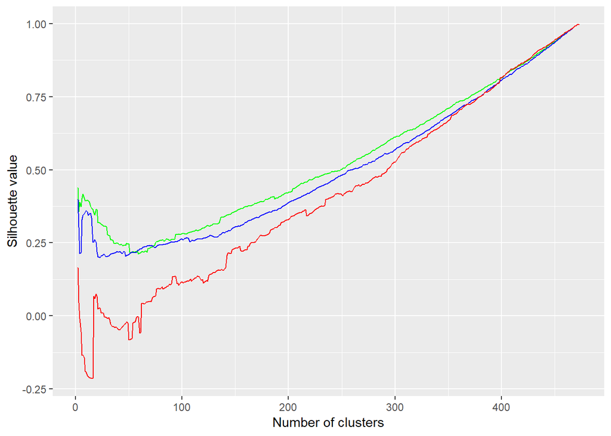

```r
ggplot() +
  geom_line(data = data.frame(x=2:473,nb$All.index), aes(x = 2:473, y = nb$All.index), color = "green") +
  geom_line(data = data.frame(x=2:473,nb1$All.index), aes(x = 2:473, y = nb1$All.index), color = "blue") +
  geom_line(data = data.frame(x=2:473,nb2$All.index), aes(x = 2:473, y = nb2$All.index), color = "red") +
  xlab('Number of clusters') +
  ylab('Silhouette value')
```

Here we have a clear example of how does Silouette index works.

We can tell from this picture that choosing a cluster with k=0-20, seems to be the best option. Afterwards, we have better silhouette indexes values, but are caused by the large number of clusters.

We alrredy know that the silhouette index will decrease until a turning point. Then, it will start increasing due to the effect of having too many clusters. In order to choose the best cluster we have to consider more options that just the silhouette index. Such as the number of clusters that we are using.

We can tell that the best results obtained for the silhouette index are the ones calculated by the *average* method. Then, we find the *complete* distance. And finally the *single* distance.

According to the number of clusters and the silhouette measure I would say that the best clusterizations will be from 5-8 clusters with average linkage.

If we check which is the number of cluster that optimizes the silhouette index, we get:

```r
var.eu.alt<-plot.Silhouette(hcut.eu.av, data.frame, range=5:60)
var1.eu.alt<-plot.Silhouette(hcut.eu.comp, data.frame, range=5:60)
var2.eu.alt<-plot.Silhouette(hcut.eu.sing, data.frame, range=5:60)

cat("Best cluster K for average:", which.max(var.eu.alt$vector.sil)+5, "\n","Best cluster K for complete:", which.max(var1.eu.alt$vector.sil)+5, "\n","Best cluster K for single:", which.max(var2.eu.alt$vector.sil)+5)
```

```
## Best cluster K for average: 7
##  Best cluster K for complete: 7
##  Best cluster K for single: 20
```

```r
hcut.av.7 <- hcut(dist(data.scaled), k=7, hc_method = "average", hc_metric = "euclidean")
hcut.comp.7 <- hcut(dist(data.scaled), k=7, hc_method = "complete", hc_metric = "euclidean")
hcut.sing.7 <- hcut(dist(data.scaled), k=20, hc_method = "single", hc_metric = "euclidean")
```

The clusters that we get are the following:

```r
p1.1<-fviz_silhouette(hcut.av.7)
```

```
##   cluster size ave.sil.width
## 1       1   35          0.43
## 2       2   64          0.42
## 3       3  107          0.26
## 4       4  198          0.56
## 5       5    6          0.51
## 6       6   62          0.22
## 7       7    2          0.21
```

```r
p2.1<-fviz_silhouette(hcut.comp.7)
```

```
##   cluster size ave.sil.width
## 1       1   39          0.32
## 2       2  196          0.52
## 3       3   58          0.44
## 4       4   40          0.28
## 5       5   68          0.20
## 6       6   41         -0.21
## 7       7   32          0.20
```

```r
p3.1<-fviz_silhouette(hcut.sing.7)
```

```
##    cluster size ave.sil.width
## 1        1  197         -0.22
## 2        2    1          0.00
## 3        3  256          0.22
## 4        4    1          0.00
## 5        5    1          0.00
## 6        6    1          0.00
## 7        7    2          0.35
## 8        8    1          0.00
## 9        9    1          0.00
## 10      10    1          0.00
## 11      11    1          0.00
## 12      12    1          0.00
## 13      13    1          0.00
## 14      14    3          0.50
## 15      15    1          0.00
## 16      16    1          0.00
## 17      17    1          0.00
## 18      18    1          0.00
## 19      19    1          0.00
## 20      20    1          0.00
```

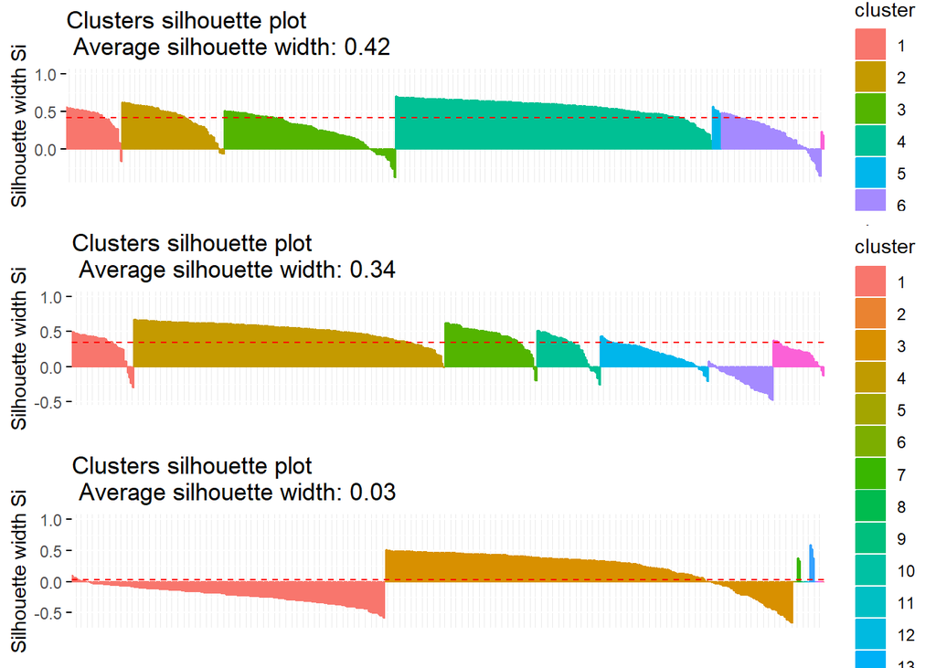

```r
grid.arrange(p1.1, p2.1, p3.1, nrow=3, ncol=1)
```

### How good does HC performs for sporulation?

In the case of the sporulation data, K was around 7 (Chu et al. used K = 7) and l = 7. Thus our data values are points in the l dimensional Euclidean space. The silhouette index was alrredy telling us that 7 was the best clusterization for this dataset.

If we double check the results obtained before, we can see that the best cluster obtainded round K=7. So I will say that we have a good performance.

# Part 2: SOM + Hierarchical clustering

SOM will be used to represent our data patterns in 2-dimensions. Kohonen networks are very useful because they manage to represent similar features very close. So, similar data are displayed very close in the map.

```r
load(file="savedData/kohonen_reference.RData")
```

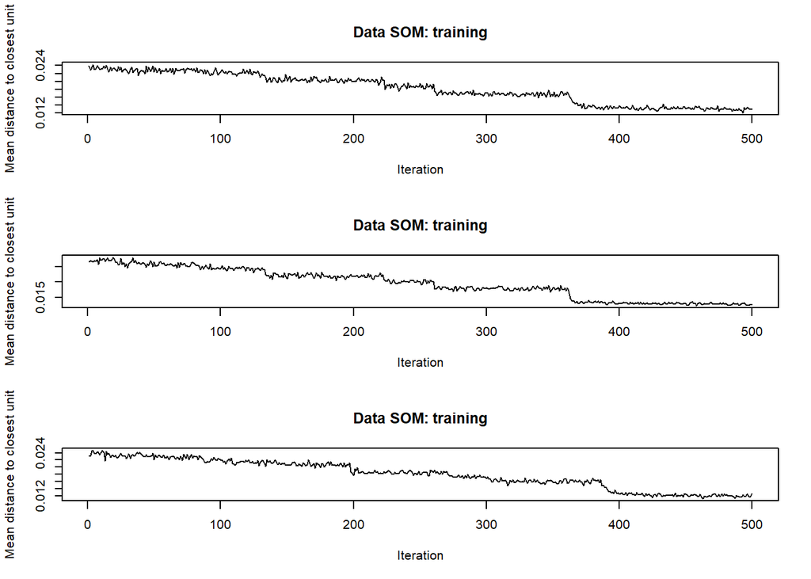

```r
par(mfrow = c(3, 1))
plot(kohmap.referencia, type="changes", main="Data SOM: training")
plot(kohmap.increased.alpha, type="changes", main="Data SOM: training")
plot(kohmap.incresed.grid, type="changes", main="Data SOM: training")
```

We are going to see how dows SOM classification changes if we vary the alpha and the grid. We have alrredy choosed a rlen=80.

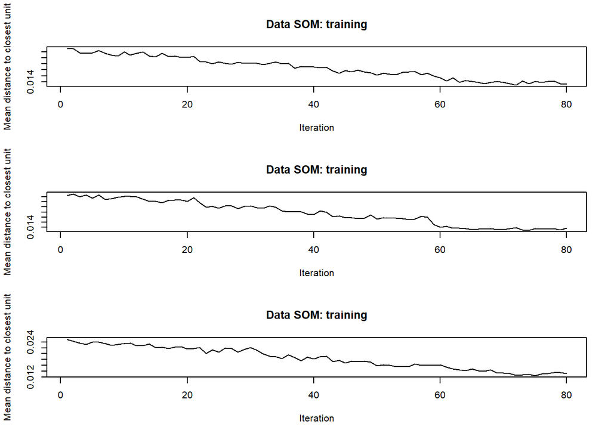

```r
kohmap.referencia <- som(scale(data.frame[,2:ncol(data.frame)]), grid = somgrid(7, 6, "hexagonal"), rlen=80, alpha =c(0.08,0.01))
kohmap.increased.alpha <- som(scale(data.frame[,2:ncol(data.frame)]), grid = somgrid(7, 6, "hexagonal"), rlen=80, alpha =c(0.4,0.1))
kohmap.incresed.grid <- som(scale(data.frame[,2:ncol(data.frame)]), grid = somgrid(8, 7, "hexagonal"), rlen=80, alpha =c(0.08,0.01))

par(mfrow = c(3, 1))
plot(kohmap.referencia, type="changes", main="Data SOM: training")
plot(kohmap.increased.alpha, type="changes", main="Data SOM: training")
plot(kohmap.incresed.grid, type="changes", main="Data SOM: training")
```

For this Kohonen maps we have the following results:

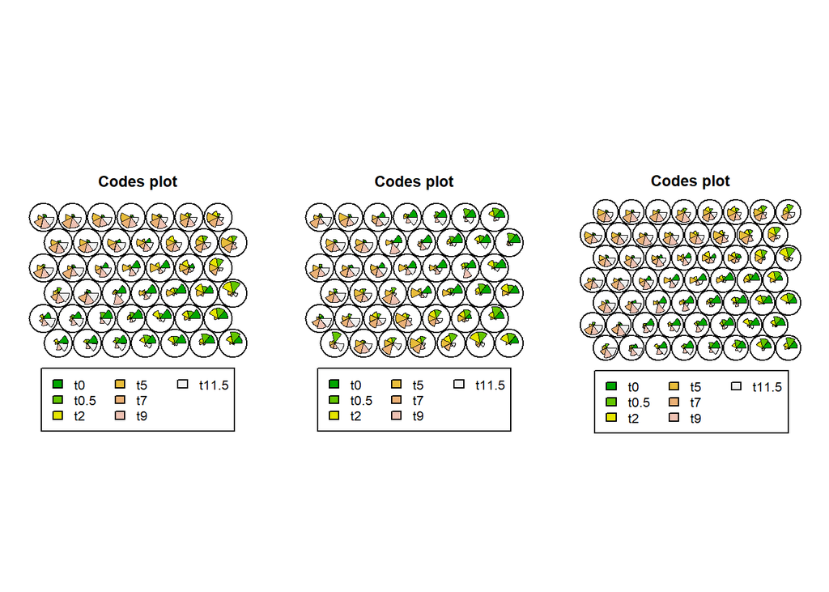

```r
par(mfrow = c(1,3))
plot(kohmap.referencia, type="codes")
plot(kohmap.increased.alpha, type="codes")
plot(kohmap.incresed.grid, type="codes")
```

This is very strinking, but we have no way we can tell which one is the best. That takes us to the next part. As we saw before we obtain the same results for euclidean an correlatin, so we are going to focus from now on just in euclidean distance in order to simplify.

## Hierarchical Clustering with Connectivity Constains

In order to implement connectivity constrains we have to factor the distance of each cluster to another cluster on the SOM map. Calculate distances on a hexagonal map is not trivial. We are going to use a function that provides the package kohonen for this task.

```r
list.kohomap<-list()
list.kohomap[[1]]<-kohmap.referencia
list.kohomap[[2]]<-kohmap.increased.alpha
list.kohomap[[3]]<-kohmap.incresed.grid

k<-7

select.types<-c("average", "complete", "single")
xclass<-c("reference", "alpha", "sigmoid")

calculate.comb<-function( list.kohomap, k,select.types , xclass){
  code.dists.list <- sapply(1:length(list.kohomap), function(x) object.distances(list.kohomap[[x]], type = "codes"))
  # Aqu? se guardan en [[x]] la lista
  cluster.list <- lapply(1:length(select.types), function(x)
    sapply(1:length(code.dists.list), function(y)
      mean(
        silhouette(
          cutree(
            hclust(code.dists.list[[x]], method = select.types[y])
            ,k=k)
          , code.dists.list[[x]])[,3]
        )
      )
    )
  data<-rbind(cluster.list[[1]],cluster.list[[2]],cluster.list[[3]] )
  colnames(data)<- select.types
  rownames(data)<- xclass
  return(data)
}


list.matrix.silhouettes<-calculate.comb(list.kohomap,k,select.types,xclass)
cat("Results for Silhouette index with k=",k,"\n")
```

```
## Results for Silhouette index with k= 7
```

```r
print(list.matrix.silhouettes)
```

```
##             average  complete      single
## reference 0.5013396 0.5013396 -0.04201257
## alpha     0.3272022 0.3846407 -0.47027017
## sigmoid   0.5506511 0.4997414  0.15690931
```

Here we can check how does the result chaged due to the variation of the parameters that we set before.

If we check this results over the map we will see:

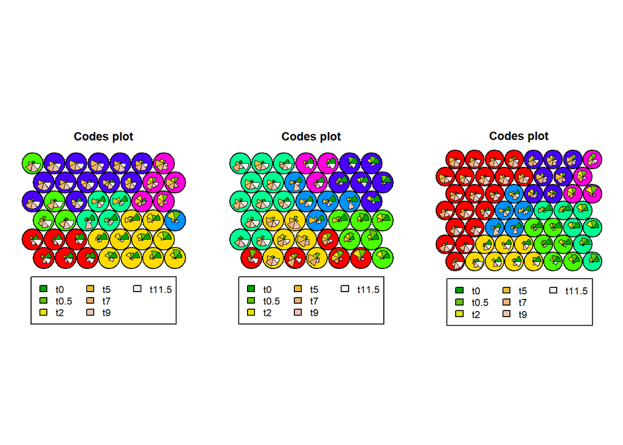

```r
par(mfrow = c(1,3))
gc = cutree(hcut(dist(kohmap.referencia$codes[[1]])), 7)
plot(kohmap.referencia, type="codes", bgcol=rainbow(7)[gc])
gc1 = cutree(hcut(dist(kohmap.increased.alpha$codes[[1]])), 7)
plot(kohmap.increased.alpha, type="codes", bgcol=rainbow(7)[gc1])
gc2 = cutree(hcut(dist(kohmap.incresed.grid$codes[[1]])), 7)
plot(kohmap.incresed.grid, type="codes", bgcol=rainbow(7)[gc2])
```

I think that it can be very interesting to see the evolution of this result through different clusters to check the conclusions obtained before.

```r
load(file="savedData/matrixSil.RData")
```

First of all we have to extract the data.

```r
list.silhouette.reference<-data.frame()
list.silhouette.reference<-t(rbind(sapply(1:length(list.matrix.silhouettes), function(i) list.matrix.silhouettes[[i]][1,])))
list.silhouette.alpha<-data.frame()
list.silhouette.alpha<-t(rbind(sapply(1:length(list.matrix.silhouettes), function(i) list.matrix.silhouettes[[i]][2,])))
list.silhouette.sigmoid<-data.frame()
list.silhouette.sigmoid<-t(rbind(sapply(1:length(list.matrix.silhouettes), function(i) list.matrix.silhouettes[[i]][3,])))
```

Once we have all the data, we can plot it.

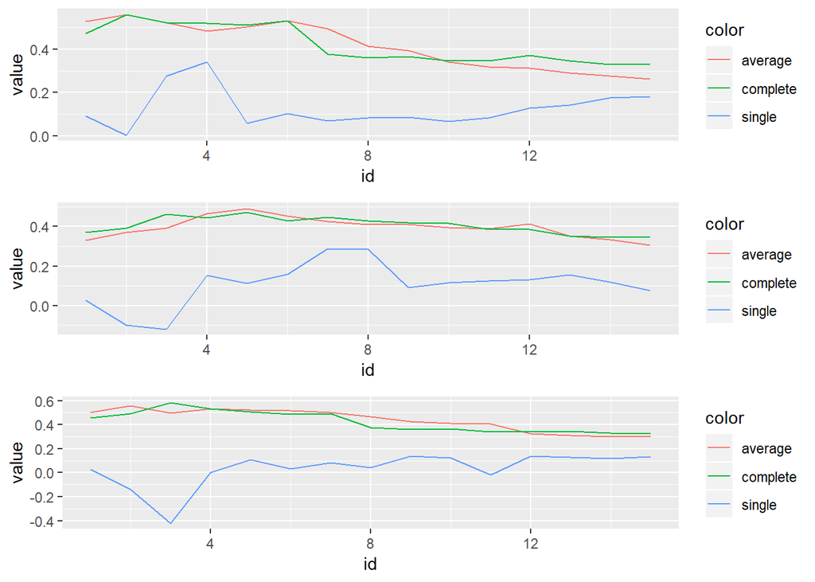

```r
df.ref <- data.frame(id = 1:(length(list.silhouette.reference)/3),
                list.silhouette.reference)
df.ref <- melt(df.ref ,  id.vars = 'id', variable.name = 'color')
p1<-ggplot(df.ref, aes(id,value)) + geom_line(aes(colour = color))

df.alp <- data.frame(id = 1:(length(list.silhouette.alpha)/3),
                list.silhouette.alpha)
df.alp <- melt(df.alp ,  id.vars = 'id', variable.name = 'color')
p2<-ggplot(df.alp, aes(id,value)) + geom_line(aes(colour = color))

df.sig <- data.frame(id = 1:(length(list.silhouette.sigmoid)/3),
                list.silhouette.sigmoid)
df.sig <- melt(df.sig ,  id.vars = 'id', variable.name = 'color')
p3<-ggplot(df.sig, aes(id,value)) + geom_line(aes(colour = color))

grid.arrange(p1, p2, p3, nrow = 3)
```

If we compare this results with the ones that we obtained before, just using hierarchical clustering. We can see a significant increase in the results. As expected, we are having best clusterizations if we apply before hierarchical clutering SOM.

As expected, we can tell that applying SOM before hierarchical clustering improves the performance of hierarchical clustering. Also, we have seen that the alpha parameter is very important and adjusting it correctly is very important in order to have a good performance of the clusters.

# Comparison with paper’s conclusion

Despite the fact that we can get good result’s just applying hierarchical clustering, we have seen that they can be improved using before SOM.

In the paper says that , the performance of correlation-based hierarchical clustering and model-based clustering (is what we do in SOM) appear to be on opposite extremes, depending on what validation measure one employs. Which means that for this case the results obtained can change drastically by using another validation method, in stead of the silhouette index.